# 201.7. SSObject table

For the Rubin Science Platform at data.lsst.cloud.  
Data Release: [Data Preview 1](https://dp1.lsst.io/)  
Container Size: large  
LSST Science Pipelines version: r29.2.0  
Last verified to run: 2025-09-02  
Repository: github.com/lsst/tutorial-notebooks

**Learning objective:** To understand the contents of the `SSObject` table and how to access it.

**LSST data products:** `SSObject`

**Packages:** `lsst.rsp`, `lsst.daf.butler`

**Credit:** Originally developed by the Rubin Community Science team. Please consider acknowledging them if this notebook is used for the preparation of journal articles, software releases, or other notebooks.

**Get Support:** Everyone is encouraged to ask questions or raise issues in the [Support Category](https://community.lsst.org/c/support) of the Rubin Community Forum. Rubin staff will respond to all questions posted there.

## 1. Introduction

The `SSObject` table contains linked Solar System objects (groupings of difference image detections). It includes the `ssObjectId` for each unique Solar System object, the number of LSST observations, `numObs`, for each Solar System object, and the date the LSST first linked and submitted the discovery observations to the MPC, which may be NULL if the object is not an LSST discovery.

- TAP table name: `dp1.SSObject`
- butler table name: `ss_object`
- columns: 3
- rows: 431

**Related tutorials:** The TAP and butler data access services are demonstrated in the 100-level "How to" tutorials.

### 1.1. Import packages

Import standard python package `numpy`.

From the `lsst` package, import modules for the TAP service and the butler.

```python
import numpy as np
import matplotlib.pyplot as plt
from lsst.rsp import get_tap_service
from lsst.daf.butler import Butler
```

### 1.2. Define parameters and functions

Create an instance of the TAP service, and assert that it exists.

```python
service = get_tap_service("tap")
assert service is not None
```

Create an instance of the Rubin data butler, and assert that it exists.

```python
butler = Butler('dp1', collections="LSSTComCam/DP1")
assert butler is not None
```

## 2. Schema (columns)

To browse the table schema visit the [Rubin schema browser](https://sdm-schemas.lsst.io/), or use the TAP service via the Portal Aspect or as demonstrated in Section 2.1.

### 2.1. Retrieve table schema

To retrieve the table schema, define a query for the schema columns of the `SSObject` table and run the query job.

```python
query = "SELECT column_name, datatype, description, unit " \
        "FROM tap_schema.columns " \
        "WHERE table_name = 'dp1.SSObject'"
job = service.submit_job(query)
job.run()
job.wait(phases=['COMPLETED', 'ERROR'])
print('Job phase is', job.phase)
if job.phase == 'ERROR':
    job.raise_if_error()
```

```
Job phase is COMPLETED
```

Retrieve the query results and display them as an `astropy` table with the `to_table()` attribute.

```python
assert job.phase == 'COMPLETED'
results = job.fetch_result().to_table()
results
```

*Table length=3*

| column_name str64 | datatype str64 | description str512 | unit str64 |
| --- | --- | --- | --- |
| discoverySubmissionDate | double | The date the LSST first linked and submitted the discovery observations to the MPC. May be NULL if not an LSST discovery. The date format will follow general LSST conventions (MJD TAI, at the moment). | d |
| numObs | int | Number of LSST observations of this object |  |
| ssObjectId | long | Unique identifier. |  |

Option to print every column name as a list.

```python
# for col in results['column_name']:
#     print(col)
```

Delete the job, but not the `results`.

```python
del query
job.delete()
```

### 2.2. Columns

The DP1 data release `SSObject` table contains three columns.

#### 2.2.1. Solar System Object Id

The long integer that uniquely identifies each Solar System object.

- `ssObjectId`

#### 2.2.2. Number of observations

The number of LSST observations for each Solar System object:

- `numObs`

#### 2.2.3. Discovery submission date

The date the LSST first linked and submitted the discovery observations to the MPC:

- `discoverySubmissionDate`

This value may be NULL if the object is not an LSST discovery. The date format will follow general LSST conventions (MJD TAI, at the moment).

## 3. Data access

The `SSObject` table is available via the TAP service and the butler.

**Recommended access method:** TAP.

### 3.1. TAP (Table Access Protocol)

The `SSObject` table is stored in Qserv and accessible via the TAP services using ADQL queries.

#### 3.1.1. Demo query

```python
query = "SELECT ssObjectId, numObs, discoverySubmissionDate "\
        "FROM dp1.SSObject " \
        "ORDER BY ssObjectId ASC "
job = service.submit_job(query)
job.run()
job.wait(phases=['COMPLETED', 'ERROR'])
print('Job phase is', job.phase)
if job.phase == 'ERROR':
    job.raise_if_error()
```

```
Job phase is COMPLETED
```

Fetch the results as an `astropy` table.

```python
assert job.phase == 'COMPLETED'
results = job.fetch_result().to_table()
print(len(results))
```

```
431
```

Option to display the table.

```python
# results
```

```python
job.delete()
del results
```

#### 3.1.2. Joinable tables

The `SSObject` table can be joined to the `SSSource` table on the column `ssObjectId`.

The `SSSource` table contains single-epoch solar system source information corresponding to a specific difference image detection.

The following query joins the `SSObject` and `SSSource` tables. Columns returned include the `SSObject` and `SSSource` unique identifiers, the number of observations from the `SSObject` table, and the heliocentric and topocentric distances from the `SSSource` table.

```python
query = "SELECT sso.ssObjectId, sso.numObs, "\
        "sss.heliocentricDist, sss.topocentricDist " \
        "FROM dp1.SSObject AS sso " \
        "JOIN dp1.SSSource AS sss ON sso.ssObjectId = sss.ssObjectId " \
        "ORDER BY sso.ssObjectId ASC"
```

```python
job = service.submit_job(query)
job.run()
job.wait(phases=['COMPLETED', 'ERROR'])
print('Job phase is', job.phase)
if job.phase == 'ERROR':
    job.raise_if_error()
```

```
Job phase is COMPLETED
```

```python
assert job.phase == 'COMPLETED'
results = job.fetch_result().to_table()
print(len(results))
```

```
5988
```

Show that this query returned data for 431 unique objects, with an average of $\sim14$ source measurements each.

```python
values, counts = np.unique(results['ssObjectId'], return_counts=True)
print(len(values))
print(np.mean(counts))
```

```
431
13.893271461716937
```

Option to display the table.

```python
# results
```

Plot histograms of the heliocentric and topocentric distances for all Solar System object sources.

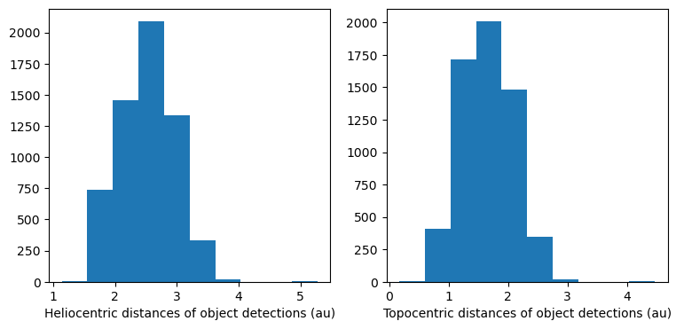

```python
fig, (ax1, ax2) = plt.subplots(1, 2, figsize=(9, 4))

ax1.hist(results['heliocentricDist'])
ax2.hist(results['topocentricDist'])

ax1.set_xlabel('Heliocentric distances of object detections (au)')
ax2.set_xlabel('Topocentric distances of object detections (au)')

plt.show()
```

> **Figure 1:** Histograms of the heliocentric and topocentric distances for all Solar System object sources.

Clean up.

```python
job.delete()
del results, values, counts
```

### 3.2. Butler

TAP is the recommended way to access the solar system object table, but the butler can be used to retrieve the same table information.

Show that the `ss_object` table has no dimensions. For DP1, it can only be retrieved from the butler in full.

```python
butler.get_dataset_type('ss_object')
```

```
DatasetType('ss_object', {}, ArrowAstropy)
```

```python
butler.get_dataset_type('ss_object').dimensions.required
```

```
{}
```

#### 3.2.1. Demo query

Define the columns to retrieve.

```python
col_list = ['ssObjectId', 'numObs', 'discoverySubmissionDate']
```

Get the data from the butler.

```python
results = butler.get('ss_object', parameters={'columns': col_list})
print(len(results))
```

```
431
```

Option to display the results.

```python
# results
```

As an example, plot a histogram of the number of sources for each object.

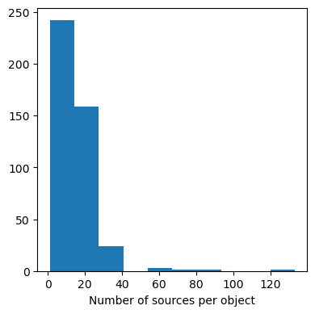

```python
fig, ax = plt.subplots(figsize=(4, 4))
ax.hist(results['numObs'])
plt.xlabel('Number of sources per object')
plt.tight_layout()
plt.show()
```

Clean up.

```python
del col_list, results
```